# Sex-biased miRNA analysis

Cadia Chan

January 17, 2022

To run: Set working directory “To Source File Location”.

## Updates

- 2021/03/17: Added in correlation plot comparing PD22-PD12 fold change in females vs males
- 2021/06/04: Added significance indicator for miRNA expression plots
- 2022/01/17: Removed age comparisons from analysis

## Load in libraries and source scripts

```r
library(ggplot2)
library(ggrepel)
library(ggpubr)
library(gProfileR)
library(dplyr)
library(reshape2)
library(EDASeq)
library(RUVSeq)
library(pheatmap)
library(RColorBrewer)
library(edgeR)
library(ggfortify)
library(dendextend)
library(gridExtra)
library(colorspace)
library(LaCroixColoR)
library(UpSetR)
library(scales)
library(openxlsx)
library(scales)
library(knitr)

source("pit_srna_puberty_functions_2020-09-22.R")
```

## Make count matrix

For each sample, counts are loaded in as 1) known mature miRNA counts, 2) novel miRNA counts A novel miRNA key table is made: novel miRNAs are renamed here as novel1, novel2,…noveln The mature sequence of each novel miRNA is kept track in the table A raw count matrix is then created containing both known and novel miRNAs (rows) with each sample (columns)

```r
#### Make count matrix ####
dir.create("output_files")
files <- list.files("input_files/")
mature_files <- files[which(sapply(files, function(x) grepl("mature", x)))]
novel_files <- files[which(sapply(files, function(x) grepl("novel", x)))]
files <- files[c(which(files %in% mature_files), which(files %in% novel_files))]
sample_id <- unique(substr(files, 1, 10))

full_novel_mirdeep <- bind_rows(lapply(novel_files, function(x) read.csv(paste0("input_files/", x), sep = "\t", header = T) %>%
                                           filter(miRDeep2.score >= 2, rfam.alert == "-") %>%
                                         mutate(sample = x)))
novel_mirdeep <- unique( dplyr::select(full_novel_mirdeep, consensus.mature.sequence, precursor.coordinate) %>%
                           mutate(precursor.coordinate = gsub("..", "-", precursor.coordinate, fixed = T)))

novel_mirdeep <- unique(bind_rows(lapply(novel_files, function(x) read.csv(paste0("input_files/", x), sep = "\t", header = T) %>%
                                           filter(miRDeep2.score >= 2, rfam.alert == "-") %>%
                                           dplyr::select(consensus.mature.sequence, precursor.coordinate) %>%
                                           mutate(precursor.coordinate = gsub("..", "-", precursor.coordinate, fixed = T)))))
novel_mirdeep <- aggregate(novel_mirdeep$precursor.coordinate, by = list(novel_mirdeep$consensus.mature.sequence), toString) %>%
  mutate(id = paste0("novel", 1:nrow(.)))
colnames(novel_mirdeep) <- c("consensus.mature.sequence", "precursor.coordinate", "id")

novel_mirdeep_test <- unique(inner_join(novel_mirdeep,
                                dplyr::select(full_novel_mirdeep, consensus.mature.sequence,
                                              miRDeep2.score, sample), by = "consensus.mature.sequence"))

kable(head(novel_mirdeep), caption = "First 5 novel miRNAs with mature sequence and precursor coordinates")
```

| consensus.mature.sequence | precursor.coordinate | id |
| --- | --- | --- |
| aagacugggccugaugguuu | chr8:4247551-4247621:+ | novel1 |
| accgaucccggguuagucuccu | chr7:19327283-19327344:+ | novel2 |
| acucucucacucugcaugguu | chr17:24720771-24720835:+, chr17:24720771-24720838:+, chr17:24720771-24720836:+, chr17:24720771-24720839:+, chr17:24720771-24720840:+ | novel3 |
| agacgggcucucaugcugacaga | chr13:24980054-24980118:+, chr13:24980055-24980118:+ | novel4 |
| aggaaucuggaaaacaugggcgu | chr3:69593552-69593616:- | novel5 |
| aggucugggagucugaggucc | chr12:109656346-109656414:+ | novel6 |

```r
write.table(novel_mirdeep, "output_files/novel_mirna_list.txt", sep = "\t", quote = F, col.names = T, row.names = F)

novel_counts <- lapply(novel_files, function(x) read.csv(paste0("input_files/", x), sep = "\t", header = T) %>%
                         filter(miRDeep2.score >= 2) %>%
                         select(consensus.mature.sequence, total.read.count) %>%
                         inner_join(., novel_mirdeep, by = "consensus.mature.sequence"))
novel_counts <- lapply(novel_counts, function(x) aggregate(x$total.read.count, by = list(x$consensus.mature.sequence, x$id), sum))
names(novel_counts) <- novel_files
novel_counts <- lapply(names(novel_counts), function(i) mutate(novel_counts[[i]], filename = i, type = "novel"))
novel_df <- bind_rows(novel_counts)

mature_counts <- lapply(mature_files, function(x) read.csv(paste0("input_files/", x), sep = "\t", header = T) %>% filter(miRDeep2.score >= 2) %>%
                          select(mature.miRBase.miRNA, total.read.count) %>% mutate(id = sapply(as.character(mature.miRBase.miRNA), function(x) strsplit(x, "_")[[1]][1])))
mature_counts <- lapply(mature_counts, function(x) aggregate(x$total.read.count, by = list(x$mature.miRBase.miRNA, x$id), sum))
names(mature_counts) <- mature_files
mature_counts <- lapply(names(mature_counts), function(i) mutate(mature_counts[[i]], filename = i, type = "mature"))
mature_df <- bind_rows(mature_counts)

colnames(novel_df)[1:3] <- colnames(mature_df)[1:3] <- c("fullid", "id", "value")
count_df <- rbind(novel_df, mature_df) %>% mutate(sample = substr(filename, 1, 7), batch = sapply(filename, function(x) strsplit(x, "_")[[1]][3]))

countmat <- dcast(count_df, id~sample)
countmat[is.na(countmat)] <- 0
kable(countmat[1:5, 1:6], caption = "Example of 5 miRNAs (alphabetical order) for 5 samples")
```

Example of 5 miRNAs (alphabetical order) for 5 samples

| id | Pd12F_1 | Pd12F_2 | Pd12F_3 | Pd12F_4 | Pd12M_1 |
| --- | --- | --- | --- | --- | --- |
| mmu-let-7a-5p | 15408 | 9683 | 12370 | 46307 | 6538 |
| mmu-let-7b-5p | 17877 | 14166 | 15081 | 19470 | 16326 |
| mmu-let-7c-5p | 56794 | 39471 | 46028 | 79020 | 28927 |
| mmu-let-7d-5p | 9393 | 6526 | 8846 | 23587 | 5056 |
| mmu-let-7e-5p | 5808 | 4120 | 4162 | 9736 | 3531 |

```r
write.table(countmat, "output_files/pit_srna-seq_unfiltered_countmat.csv", sep = "\t", quote = F, row.names = F, col.names = T)
```

## Make sample condition table (metadata) and miRNA information table (featuredata)

For each sample, the sex, age, replicate number, and batch is stored parsed from filename and stored in metadata For each miRNA, store the long id and short id in featuredata

```r
#### Make metadata ####
metadata <- data.frame(fullid = sapply(novel_files, function(x) strsplit(x, "_novel")[[1]][1])) %>%
  mutate(sample = substr(fullid, 1, 7),  sex = substr(fullid, 5, 5), age = substr(fullid, 3, 4), rep = substr(fullid, 7, 7), batch = substr(fullid, 8, 10))
metadata$batch <- ifelse(metadata$batch == "_RO", "2018-12-11", "2018-01-26")
metadata <- metadata[, -1]
kable(metadata[1:5,], caption = "Metadata of 5 samples showing sex, age, replicate and batch")
```

Metadata of 5 samples showing sex, age, replicate and batch

|  | sample | sex | age | rep | batch |
| --- | --- | --- | --- | --- | --- |
| Pd12F_1_miRNA_15ul_NEB_TCAG_novel.csv | Pd12F_1 | F | 12 | 1 | 2018-01-26 |
| Pd12F_2_miRNA_15ul_NEB_TCAG_novel.csv | Pd12F_2 | F | 12 | 2 | 2018-01-26 |
| Pd12F_3_miRNA_15ul_NEB_TCAG_novel.csv | Pd12F_3 | F | 12 | 3 | 2018-01-26 |
| Pd12F_4_ROY8929_miRNA_15ul_R1_novel.csv | Pd12F_4 | F | 12 | 4 | 2018-12-11 |
| Pd12M_1_miRNA_15ul_NEB_TCAG_novel.csv | Pd12M_1 | M | 12 | 1 | 2018-01-26 |

```r
write.table(metadata, "output_files/pit_srna-seq_metadata.csv", sep = "\t", quote = F, row.names = F, col.names = T)
rownames(metadata) <- metadata$sample
metadata[, c(2,3,4,5)] <- lapply(metadata[,c(2:5)], factor)

featdata <- unique(count_df[, c(1:2)]) %>% arrange(id)
rownames(featdata) <- featdata$id
```

## Normalization using RUVseq (sRNA-seq data was sequenced in 2 batches)

RUVs was used to remove unwanted batch effects using replicate samples

```r
#### Run RUVSeq ####
rownames(countmat) <- countmat$id
countobj <- newSeqExpressionSet(as.matrix(countmat[, -1]), phenoData = AnnotatedDataFrame(metadata),
                    featureData = AnnotatedDataFrame(featdata))
print(countobj)
```

```
## SeqExpressionSet (storageMode: lockedEnvironment)
## assayData: 798 features, 45 samples
##   element names: counts, normalizedCounts, offset
## protocolData: none
## phenoData
##   sampleNames: Pd12F_1 Pd12F_2 ... Pd32M_6 (45 total)
##   varLabels: sample sex ... batch (5 total)
##   varMetadata: labelDescription
## featureData
##   featureNames: mmu-let-7a-5p mmu-let-7b-5p ... novel99 (798 total)
##   fvarLabels: fullid id
##   fvarMetadata: labelDescription
## experimentData: use 'experimentData(object)'
## Annotation:
```

```r
saveRDS(countobj, "output_files/pit_srna-seq_unfiltered_count_expressionset.rds")

metadata <- pData(countobj) %>% mutate(group = paste0("d", age, sex))
rownames(metadata) <- metadata$sample

countmat <- counts(countobj)

filter <- apply(countmat, 1, function(x) length(x[x>2])>=5)
filt_countmat <- countmat[filter, ]
mirna <- rownames(filt_countmat)
newfData <- filter(fData(countobj), id %in% rownames(filt_countmat))
rownames(newfData) <- newfData$id
set <- newSeqExpressionSet(as.matrix(filt_countmat),
                           phenoData = metadata,
                           featureData = newfData)

colors <- brewer.pal(3, "Set2")
#RLE = log-ratio of read count to median read count across sample
# plotRLE(set, outline=FALSE, ylim=c(-4, 4), col=colors[metadata$batch], )
# plotPCA(set, col=colors[metadata$batch], cex=1.2)

set <- betweenLaneNormalization(set, which="upper")
# plotRLE(set, outline=FALSE, ylim=c(-4, 4), col=colors[metadata$batch])
# plotPCA(set, col=colors[metadata$batch], cex=1.2)

design <- model.matrix(~metadata$group, data=pData(set))
y <- DGEList(counts=counts(set), group=metadata$group)
y <- calcNormFactors(y, method="upperquartile")
y <- estimateGLMCommonDisp(y, design)
y <- estimateGLMTagwiseDisp(y, design)

## Run RUVSeqS
fit <- glmFit(y, design)
differences <- makeGroups(paste0(metadata$age, metadata$sex))
ruv_set <- RUVs(set, mirna, k=3, differences)

pdf("output_files/pit_srna-seq_ruv-seq_pca.pdf", width = 6, height = 6)
plotRLE(ruv_set, outline=FALSE, ylim=c(-2, 2), col=colors[factor(metadata$batch)])
plotPCA(ruv_set, col=colors[factor(metadata$batch)], cex=1.2)
plotPCA(ruv_set, col=colors[factor(metadata$age)], cex=1.2)
plotPCA(ruv_set, col=colors[factor(metadata$sex)], cex=1.2)
discard <- dev.off()
saveRDS(ruv_set, "output_files/RUV_corrected_pit_srna-seq_counts_combined.rds")

ruv_counts <- log(normCounts(ruv_set) + 1)
ruv_cor <- cor(ruv_counts, method = "pearson")
ruv_melt <- melt(ruv_cor, na.rm = T)
pheatmap(ruv_cor, annotation = metadata[,c(2,3, 5)],
         filename="output_files/RUV_correlation_heatmap_pit_srna-seq_combined.pdf",
         width = 9, height = 8)

ruv_dists <- dist(t(ruv_counts))
ruv_distsMatrix <- as.matrix(ruv_dists)
rownames(ruv_distsMatrix) <- colnames(ruv_counts)
colnames(ruv_distsMatrix) <- NULL
colors <- colorRampPalette( rev(brewer.pal(9, "Greens")) )(255)
pheatmap(t(ruv_distsMatrix),
         clustering_distance_rows=ruv_dists,
         clustering_distance_cols=ruv_dists,
         # col=colors,
         # main = plot_title,
         annotation_col = metadata[,c(2,3, 5)],
         treeheight_row = 0,
         filename="output_files/RUV_distance_heatmap_pit_srna-seq_combined.pdf",
         width = 9, height = 8)
```

## Data QC

Low counts are first filtered from batch-normalized count matrix (CPM > 2 in 10 or more samples). edgeR is used to calculate normalization factors to scale raw library sizes. Then QC is performed to look for sample outliers by PCA and heatmap.

```r
#### Data QC ####
ruv_obj <- ruv_set
ruv_countmat <- normCounts(ruv_obj)
ruv_metadata <- pData(ruv_obj)

sample_sort <- order(ruv_metadata$sex)
ruv_metadata <- ruv_metadata[sample_sort, ]
ruv_metadata[, c(2:5)] <- lapply(ruv_metadata[, c(2:5)], factor)
ruv_countmat <- ruv_countmat[, sample_sort]

y <- DGEList(counts = ruv_countmat,
             samples = ruv_metadata,
             genes = rownames(ruv_obj))
cpmcounts <- cpm(y)
keepcounts <- which(apply(cpmcounts, 1, function(x) length(which(x > 2)) >= 10))

y <- y[keepcounts, ]
y <- calcNormFactors(y)

ruv_norm_filt <- log2(y$counts + 1)
ruv_logcpm <- log2(cpm(y) + 1)


# Make filtered novel miRNA table
filt_fdata <- filter(novel_mirdeep, id %in% rownames(ruv_logcpm))
filt_fdata <- inner_join(filt_fdata, full_novel_mirdeep, by = "consensus.mature.sequence")
filt_fdata_mirdeep_score <- aggregate(filt_fdata$miRDeep2.score, by = list(filt_fdata$id), mean)
colnames(filt_fdata_mirdeep_score) <- c("id", "mean_mirdeep_score")
filt_fdata <- unique(inner_join(filt_fdata, filt_fdata_mirdeep_score, by = "id") %>%
  select(id, consensus.mature.sequence, precursor.coordinate.x, mean_mirdeep_score, rfam.alert))
kable(filt_fdata, caption = "Novel miRNAs with CPM > 2 in 10+ samples.")
```

Novel miRNAs with CPM > 2 in 10+ samples.

|  | id | consensus.mature.sequence | precursor.coordinate.x | mean_mirdeep_score | rfam.alert |
| --- | --- | --- | --- | --- | --- |
| 1 | novel5 | aggaaucuggaaaacaugggcgu | chr3:69593552-69593616:- | 2.368571 | - |
| 36 | novel10 | aucucgcuggggccucca | chr2:28495932-28495983:+ | 2.500000 | - |
| 76 | novel15 | cagacaccucuuccucugcagc | chr2:121585983-121586051:- | 2.300000 | - |
| 116 | novel16 | ccaugcugggguggaaccuggu | chr11:113300289-113300340:+ | 2.300000 | - |
| 157 | novel21 | cucgacacaaggguuugu | chr9:118674952-118675038:-, chr9:118674952-118675037:-, chr9:118674952-118675039:- | 3517.030000 | - |
| 167 | novel22 | cugguuaguacuuggaug | chr7:58352040-58352112:+ | 92.300000 | - |
| 168 | novel28 | ggggguuggguggaggcuu | chr4:111515209-111515272:- | 2.400000 | - |
| 205 | novel32 | ucucuucugcucugugucacagc | chr3:88632210-88632276:+ | 2.121429 | - |
| 219 | novel34 | ucugugggucuguuuguccguc | chr3:55887283-55887339:- | 2.205128 | - |
| 258 | novel37 | ugauauagccaagcccgacugu | chr7:61750467-61750528:-, chr7:61750467-61750525:- | 2.200000 | - |
| 303 | novel41 | ugugggaaggaacuacaagaca | chr9:15313866-15313929:+, chr9:15313865-15313929:+, chr9:15313907-15313982:+ | 40.019048 | - |
| 345 | novel43 | uuccggagcgggaggaau | chr10:60739807-60739869:- | 2.300000 | - |
| 356 | novel46 | uugggaagcagaacuggcg | chr11:94410135-94410178:- | 2.400000 | - |
| 373 | novel51 | agaguucucuuuucuuug | chr16:12746719-12746779:+, chr16:12746718-12746779:+ | 23.618182 | - |
| 384 | novel57 | cgaugugauuucugcccagugc | chr5:114851979-114852030:+, chr5:114851978-114852030:+ | 3322.527273 | - |
| 395 | novel70 | ucuucgggggcguggguu | chr7:120917562-120917605:+ | 2.000000 | - |
| 415 | novel78 | accuuggcucuagacuguua | chr17:46257939-46257985:- | 2.200000 | - |
| 443 | novel148 | accaggaggcugagguca | chr4:131110353-131110395:+ | 2.300000 | - |
| 475 | novel184 | uccgccacccgcucugaagcg | chr14:7244755-7244808:+, chr14:6038298-6038351:+, chr14:5741650-5741703:+, chr14:5389122-5389175:+, chr14:6038298-6038353:+, chr14:7244755-7244810:+, chr14:5741650-5741705:+, chr14:5389122-5389177:+, … | 4.865957 | - |

```r
write.table(filt_fdata, "output_files/novel_mirna_list_ruv_logcpm_filtered.txt", col.names = T, row.names = F, sep = "\t", quote = F)
```

### Sample global overview

PCA plot and correlation heatmap are generated using log2-transformed RUV-seq-corrected counts.

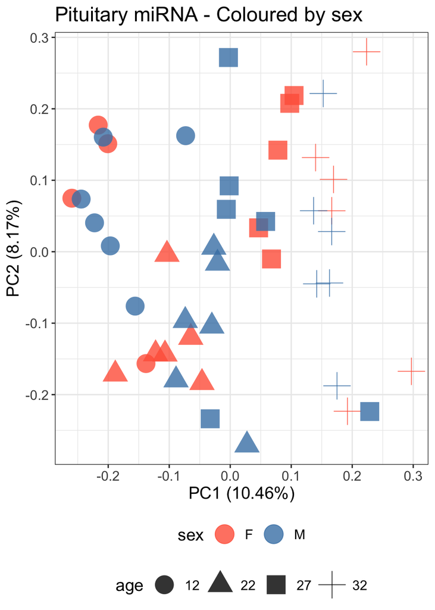

PCA plot of all miRNA samples

```r
#### Make PCA ####
prcmp <- prcomp(t(ruv_norm_filt))

sex_lab_pca <- plot_pca(ruv_norm_filt, ruv_metadata, "Pituitary miRNA - Coloured by sex", "sex", "age",
                        c("tomato", "steelblue"), label_anno = ruv_metadata$rep)

sex_pca <- plot_pca(ruv_norm_filt, ruv_metadata, "Pituitary miRNA - Coloured by sex", "sex", "age",
                    c("tomato", "steelblue"))
ggsave("output_files/mirna_pit_combined_pca_sex_coloured.pdf", sex_pca, device = "pdf", width = 5, height = 7, useDingbats = F)

pal <- brewer.pal(n = 9, "BuGn")
age_pca <- plot_pca(ruv_norm_filt, ruv_metadata, "Pituitary miRNA - Coloured by age", "age", "sex",
                    pal[c(3,5,7,9)])
batch_pca <- plot_pca(ruv_norm_filt, ruv_metadata, "Pituitary miRNA - Coloured by batch", "batch", "age",
                      c("darkmagenta", "springgreen2"))
p_all <- ggarrange(plotlist = list(sex_lab_pca, sex_pca, age_pca, batch_pca))
ggsave("output_files/mirna_pit_combined_all_pcas.pdf", p_all, device = "pdf", width = 10.5, height = 15, useDingbats = F)

print(sex_pca)
```

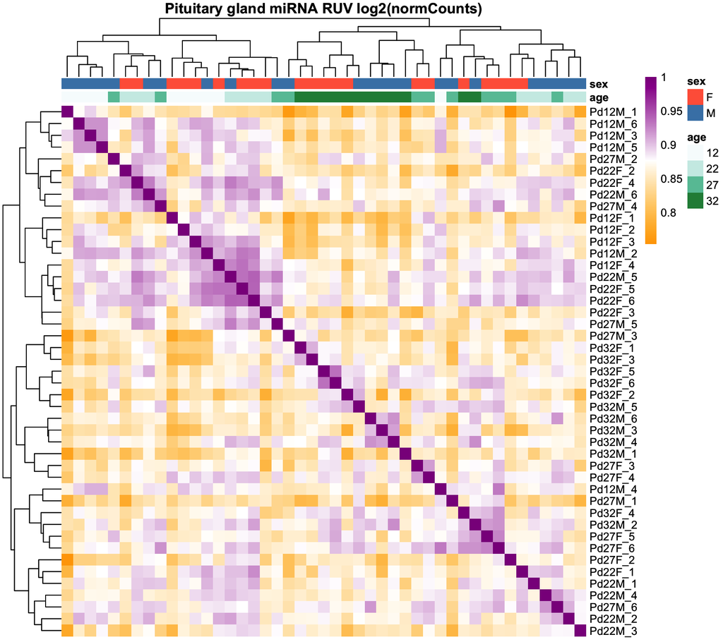

Heatmap showing correlation between all miRNA samples

```r
#### Make sample correlation heatmap ####

Var1 <- c("tomato", "steelblue")
names(Var1) <- c("F", "M")
Var2 <- pal[c(1,3,5,7)]
names(Var2) <- levels(ruv_metadata[,3])
use_anno_colors <- list(sex = Var1, age = Var2)

p <- plot_sample_dist_mat(ruv_norm_filt, ruv_metadata[, c(3, 2)], "Pituitary gland miRNA RUV log2(normCounts)",
                          use_anno_colors)
print(p)
```

```r
save_phtmap_pdf(p, "output_files/mirna_pit_ruv_log_normcounts_corr_heatmap.pdf", height = 8, width = 9)
```

```r
cor_mat <- cor(ruv_norm_filt,method="pearson")
all_cor_means <- c()
ruv_metadata$group <- factor(ruv_metadata$group)
for(i in levels(ruv_metadata$group)) {
  sub_df <- rownames(ruv_metadata[ruv_metadata$group == i, ])
  sub_df <- cor_mat[sub_df, sub_df]
  sub_melt <- melt(sub_df)
  sub_melt <- sub_melt[-which(sub_melt$Var1 == sub_melt$Var2), ]
  sub_mean <- mean(sub_melt$value)
  all_cor_means <- c(all_cor_means, sub_mean)
}
print(paste0("Range of PCC: ", min(all_cor_means), " to ", max(all_cor_means)))
```

```
## [1] "Range of PCC: 0.860731732759803 to 0.896959000994862"
```

### Expression of signature pituitary miRNAs

miRNAs selected are previously shown to be expressed in the pituitary gland.

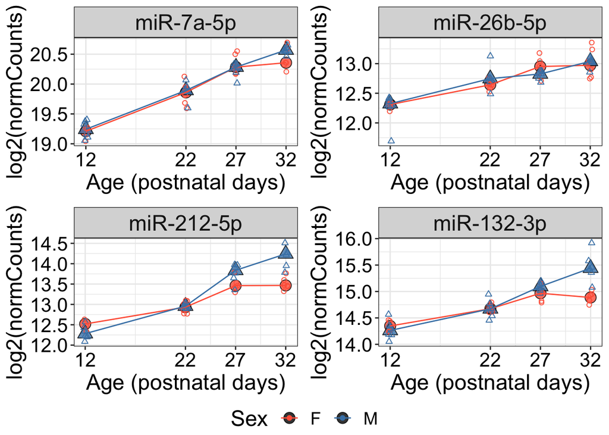

Expression of signature pituitary miRNAs

```r
pit_expr_mirna <- data.frame("mirna" = c("mmu-miR-7a-5p",  "mmu-miR-26b-5p", "mmu-miR-212-5p", "mmu-miR-132-3p"))
rownames(pit_expr_mirna) <- pit_expr_mirna$mirna
ruv_norm_pitmirna <- ruv_norm_filt[as.character(pit_expr_mirna$mirna),]
use_anno_colors <- list(sex = Var1, age = Var2)

p <- lapply(pit_expr_mirna$mirna, function(x) mirnaplot_hhtheme(x, mirna_data = ruv_norm_filt, ylabel = "log2(normCounts)"))
p_all <- ggarrange(plotlist = p, common.legend = T, legend = "bottom")
ggsave("output_files/literature_pituitary_mirnas_exprplot.pdf", plot = p_all, width = 8, height = 7, useDingbats = F)
print(p_all)
```

## Differential expression analysis

```r
#### Run edgeR ####
dir.create("output_files/edgeR")
setwd("output_files/edgeR")
knitr::opts_knit$set(root.dir = 'output_files/edgeR')
countmat_order <- match(ruv_metadata$sample, colnames(filt_countmat))
y_fil <- filt_countmat[keepcounts, countmat_order]
y_fil <- DGEList(counts = y_fil,
             samples = ruv_metadata,
             genes = rownames(y_fil))
y_fil <- calcNormFactors(y_fil)
design <- model.matrix(~0+group+W_1+W_2+W_3, y_fil$samples )

y_fil <- estimateDisp(y_fil, robust = TRUE, design = design)
fit <- glmQLFit(y_fil, design=design, robust = TRUE)

pair_contrasts <- makeContrasts(d12_sex = groupd12F - groupd12M,
                                d22_sex = groupd22F - groupd22M,
                                d27_sex = groupd27F - groupd27M,
                                d32_sex = groupd32F - groupd32M,
                                levels = design)

de_result_list <- lapply(colnames(pair_contrasts), function(x) get_edger_result(pair_contrasts, x))
names(de_result_list) <- colnames(pair_contrasts)

pval_val <- 0.05
log2FC_val <- log2(1.5)

join_lognorm <- mutate(as.data.frame(ruv_norm_filt), genes = rownames(ruv_norm_filt))
out_de_result_list <- lapply(de_result_list, function(x) inner_join(x, join_lognorm, by = "genes"))
write.xlsx(out_de_result_list, "mirna_pit_sex_all_edgeR.xlsx")
saveRDS(out_de_result_list, "mirna_pit_sex_all_edgeR.RDS")

results_df <- lapply(out_de_result_list, function(x) subset(x, FDR < pval_val & abs(logFC) > log2FC_val))
names(results_df) <- colnames(pair_contrasts)
names(results_df) <- lapply(names(results_df), function(x) gsub("_sex", " F-M", x))
write.xlsx(results_df, "mirna_pit_de_sex_sig_edgeR.xlsx")
```

### Sex-biased miRNAs

Number of sex-biased miRNAs at each age is summarized as a Upset plot (Fig 4B). Expression of all sex-biased miRNAs (log2-transformed counts) are plotted (Fig 4D, Supp Fig S6C).

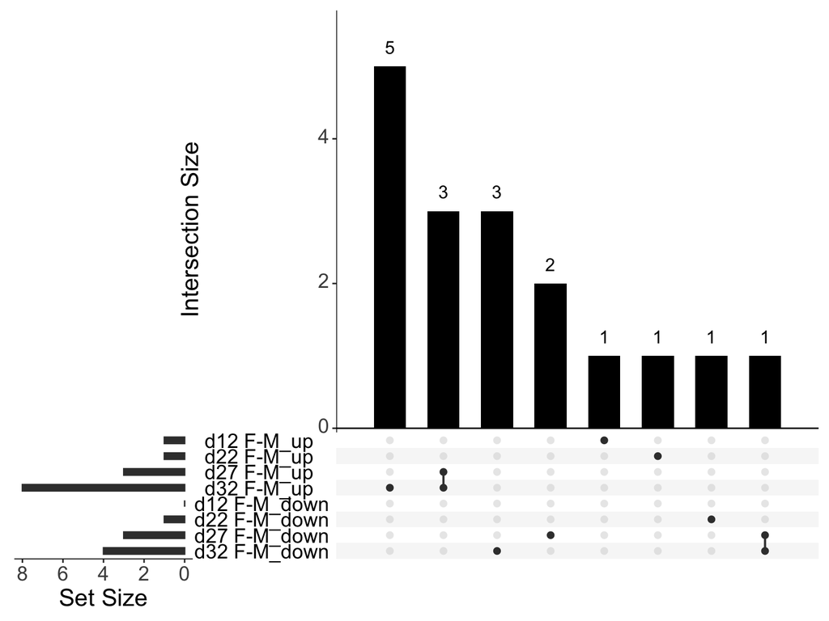

Upset plot summarizing number of sex-biased miRNAs at each profiled age

```r
#### Sex upset ####
mirna_up <- lapply(results_df[1:4], function(x) x[x$logFC > 0,])
names(mirna_up) <- paste0(names(mirna_up), "_up")
F_bias_mirnas <- bind_rows(lapply(names(mirna_up), function(x) dplyr::select(mirna_up[[x]],genes) %>% mutate(comparison = x) %>%
                                   filter(grepl("novel", genes))))
mirna_down <- lapply(results_df[1:4], function(x) x[x$logFC < 0,])
names(mirna_down) <- paste0(names(mirna_down), "_down")
M_bias_mirnas <- bind_rows(lapply(names(mirna_down), function(x) dplyr::select(mirna_down[[x]],genes) %>% mutate(comparison = x) %>%
                                    filter(grepl("novel", genes))))
mirnas <- c(lapply(mirna_up, function(x) x[,"genes"]), lapply(mirna_down, function(x) x[,"genes"]))
mirnas <- fromListx(mirnas)

sex_upset <- upset(mirnas, order.by = "freq", main.bar.color = "black",
           sets= rev(colnames(mirnas)), keep.order = T,
           text.scale = 2)

pdf("mirna_pit_sex_biased_upset.pdf",
    width = 6.5, height = 5, useDingbats = F)
print(sex_upset)
discard <- dev.off()
print(sex_upset)
```

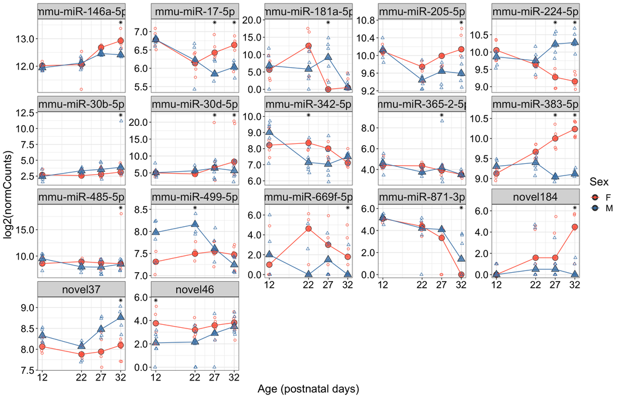

Expression of all sex-biased miRNAs

```r
#### Make sex expression plot ###

sex_df <- lapply(de_result_list[grep("sex", names(de_result_list))], function(x) subset(x, FDR < pval_val & abs(logFC) > log2FC_val))
sex_df <- bind_rows(lapply(names(sex_df), function(x) mutate(sex_df[[x]], comparison = substr(x, 1, 3))))
colnames(sex_df)[1] <- "mirna"
sex_df <- mutate(sex_df, factor = paste0(mirna, "_", comparison))

sex_mirnaplots <- mirnafactor_plot(unique(sex_df$mirna),
                 mirna_data = ruv_norm_filt,
                ylabel = "log2(normCounts)",
                input_meta = metadata,
                de_input = sex_df)
print(sex_mirnaplots)
```

```r
ggsave("mirna_pit_sex_biased_exprplot.pdf", sex_mirnaplots, device = "pdf", width = 12, height = 7, useDingbats = F)
```

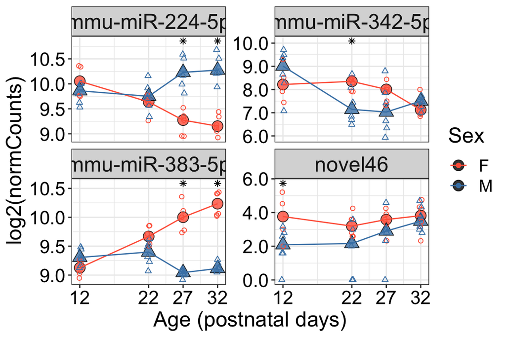

Expression of sex-biased miRNA chosen per age comparison

```r
mirna_plotlist <- mirnafactor_plot(c("novel46", "mmu-miR-342-5p", "mmu-miR-383-5p", "mmu-miR-224-5p"),
                                   mirna_data = ruv_norm_filt,
                                   ylabel = "log2(normCounts)",
                                   input_meta = metadata,
                                   de_input = filter(sex_df, mirna %in% c("novel46", "mmu-miR-342-5p", "mmu-miR-383-5p", "mmu-miR-224-5p")))
print(mirna_plotlist)
```

```r
ggsave("mirna_pit_sex_biased_examples_exprplot.pdf", mirna_plotlist, device = "pdf", width = 5, height = 3.5, useDingbats = F)
```

## Novel DE miRNAs

```r
novel_DE_mirnas <- rbind(F_bias_mirnas, M_bias_mirnas)
novel_DE_mirnas <- aggregate(novel_DE_mirnas$comparison, by = list(novel_DE_mirnas$genes), toString)
colnames(novel_DE_mirnas) <- c("id", "comparison")
novel_DE_mirnas <- inner_join(novel_DE_mirnas, novel_mirdeep, by = "id")
kable(novel_DE_mirnas, caption = "novel DE miRNAs with mature sequence, precursor coordinates, and DE comparison")
```

novel DE miRNAs with mature sequence, precursor coordinates, and DE comparison

| id | comparison | consensus.mature.sequence | precursor.coordinate |
| --- | --- | --- | --- |
| novel184 | d32 F-M_up | uccgccacccgcucugaagcg | chr14:7244755-7244808:+, chr14:6038298-6038351:+, chr14:5741650-5741703:+, chr14:5389122-5389175:+, chr14:6038298-6038353:+, chr14:7244755-7244810:+, chr14:5741650-5741705:+, chr14:5389122-5389177:+, … |
| novel37 | d32 F-M_down | ugauauagccaagcccgacugu | chr7:61750467-61750528:-, chr7:61750467-61750525:- |
| novel46 | d12 F-M_up | uugggaagcagaacuggcg | chr11:94410135-94410178:- |

```r
write.table(novel_DE_mirnas, "novel_sex_DE_mirnas.txt", sep = "\t", quote = F, col.names = T, row.names = F)
```